# Pitcher card

# Mason Black

RHP · KC

2026 · 17 G (1 GS) · 556 pitches · Apr 19 – Aug 26, 2026

Independent portfolio sample by Devin Jenkinson, not affiliated with any club. Every number is computed from public Statcast data.

Three big takeaways

1Watch

The 4-seam fastball is his most-used two-strike pitch.

37% of two-strike pitches · 32 two-strike swings so far

No pitch has 50+ two-strike swings yet, so this card does not name a put-away pitch by miss rate.

2Avoid

Limit the 4-seam fastball. It is his most damaging pitch.

xRV/100 -0.79 shrunk (raw -2.30) · .349 xwOBAcon · 118 pitches

When behind in the count he throws it 19% of the time; the sweeper grades +0.26 there instead.

3Watch

Build the sinker sample before setting a height plan.

19 swings up · 20 swings down

Rates under 50 swings are not quoted on this card.

Charts

### Movement

The ST finishes 32 in from his SI, with 29 in more glove-side run.

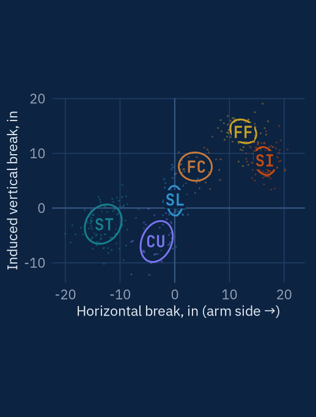

n = 533 pitches. Ellipses hold about 68% of each type; codes sit at the averages.

### Location by count

He throws 52% of pitches in the zone when behind and 62% when ahead.

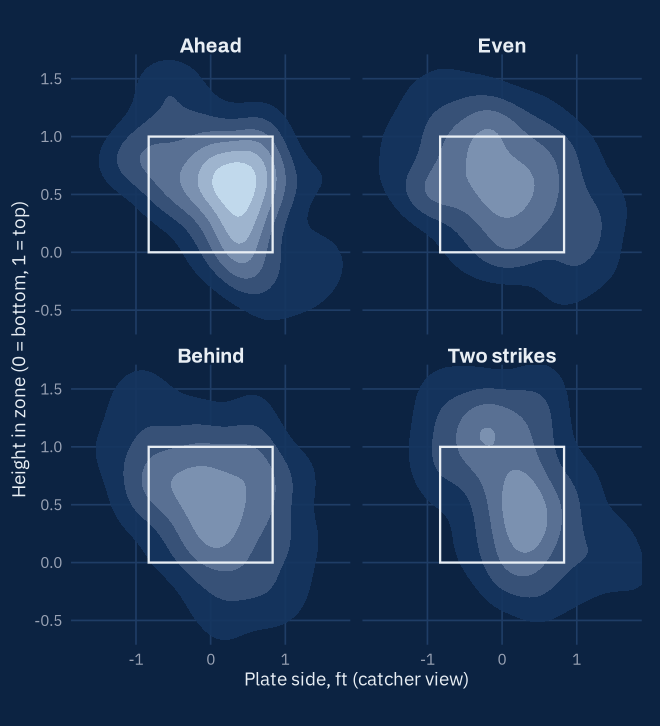

n = 533. Ahead 55 · even 181 · behind 147 · two strikes 150 pitches. Box = rule-book zone.

### Put-away

The FF is 37% of two-strike pitches vs 21% overall.

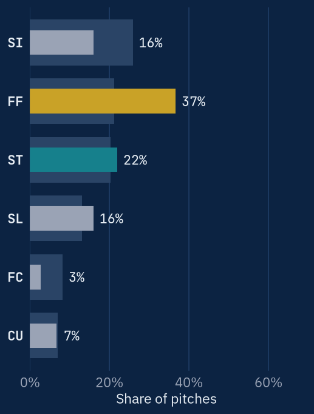

Two-strike n: FF 55, ST 33, SL 24, SI 24, CU 10, FC 4. Grey bars = overall usage; wh = whiffs per swing (shown with 50+ swings).

### Arsenal

| Pitch | # | Use | Velo | IVB | HB | VAA | Whiff | Chase | xwOBAcon | xRV/100 | Stuff+ |
| --- | --- | --- | --- | --- | --- | --- | --- | --- | --- | --- | --- |
| Sinker (SI) | 144 | 26% | 93.8 | 8.7 | +16.5 | -4.9 | 19% | 16% | .409 | -0.32 | 93 |
| 4-Seam (FF) | 118 | 21% | 94.0 | 13.9 | +12.5 | -3.8 | 16% | 30% | .349 | -0.79 | 85 |
| Sweeper (ST) | 113 | 20% | 83.0 | -2.9 | -12.9 | -7.1 | 17% | 17% | .389 | +0.26 | 98 |
| Slider (SL) | 73 | 13% | 86.9 | 1.6 | +0.1 | -6.3 | 24% | 26% | .460 | -0.51 | 96 |
| Cutter (FC) | 46 | 8% | 90.4 | 7.6 | +4.0 | -5.2 | 21% | 16% | .382 | -0.40 | 71 |
| Curveball (CU) | 39 | 7% | 81.2 | -6.1 | -3.5 | -7.9 | 16% | 13% | .309 | -0.15 | 95 |

IVB / HB in inches (HB + = arm side). VAA in degrees at the front of the plate. xRV/100 = expected run value per 100 pitches, pitcher’s view, shrunk with a 250-pitch prior. Stuff+ = this project’s shape-only model (100 = MLB average, 10 = 1 SD).

### Vs. batter hand

| Pitch | LHH # | Use | Whiff | xwOBAcon | RHH # | Use | Whiff | xwOBAcon |
| --- | --- | --- | --- | --- | --- | --- | --- | --- |
| SI | 36 | 16% | – | .398 | 108 | 35% | – | .417 |
| FF | 63 | 28% | – | .529 | 55 | 18% | – | .348 |
| ST | 45 | 20% | – | .420 | 68 | 22% | – | .270 |
| SL | 22 | 10% | – | .391 | 51 | 17% | – | .436 |
| FC | 35 | 15% | – | .501 | 11 | 4% | – | .401 |
| CU | 27 | 12% | – | .306 | 12 | 4% | – | .022 |

Use = share of pitches to that side. Whiff = whiffs per swing, shown with 50+ swings.